# MY472 Final Assignment

2024-01-10

My public repository for this assignment can be found [here](https://github.com/lorism7/MY472_Final.git).

### Option 1

“In the United Kingdom, a police officer has powers to stop and search any individual if the officer has ‘reasonable grounds’ to suspect the individual is carrying certain items or, under some other conditions, if a senior police officer has granted approval (see here for details). Are there biases in who experiences stop and search by the police?”

### Introduction

This analysis examines potential biases in the UK’s police stop and search practices, focusing on officer-perceived ethnicity. We sourced and preprocessed data from the UK Police database and the Office for National Statistics, concentrating on demographic and geographic factors. Our key metric is the proportion of false stop and searches by ethnicity and region, a potential indicator of biased policing. Our methodology involves visualization and statistical analysis to understand these law enforcement practices and their implications for fairness and public trust.

### Data

#### UK Police Data API

We gathered 2021 stop and search data from the UK Police API, by police force, for detailed regional insights. This approach was chosen for its precision in capturing localized policing patterns and ensuring a comprehensive view across different regions. Each police force’s data was collected monthly, ensuring granularity in the time sequence and allowing for the detection of temporal trends.

The year 2021 was specifically selected to balance the depth of data with practicality. It offers a recent snapshot, reflecting contemporary policing practices and societal contexts, making our analysis both relevant and timely.

During data processing, we ensured consistency and uniformity in the datasets. This involved standardizing the data structure across different records, removing missing data, and merging the datasets to form a single, cohesive database. Key variables included geographic coordinates and officer-defined ethnicity.

Another critical aspect of our analysis involved the creation of a new variable to identify false stop and searches. This was defined as instances where the outcome of a stop and search was not linked to the object of the search (FALSE). By calculating the proportion of false stop and searches for each ethnicity, we could gain insights into potential biases in policing practices.

For efficiency and reproducibility, we saved the processed data as a CSV file. The “ne_10m_admin_0_countries” shapefile was used for spatial analysis.

#### Additional Source

To handle and clean the demographic data obtained from the UK Office for National Statistics, a methodical approach of filtering was applied. The data was then enriched by calculating the total percentage of non-white ethnic groups in each area (summing the percentages of these groups row-wise). Finally, we merged with a shapefile, titled “Local Authority Districts” and containing geographic boundaries of UK local authority districts as of May 2021, which offered a precise and contextually relevant geographical framework for the study.

### Analysis

##### Figure 1: Ethnic Demographics and Police Stop-and-Searches in the UK

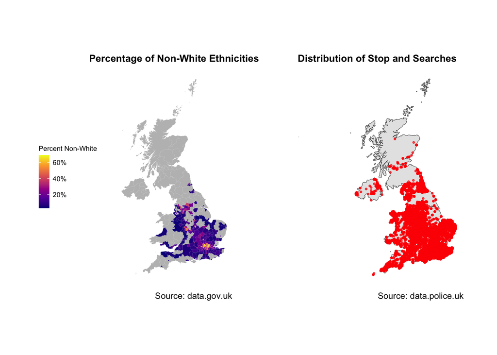

##### Figure 2

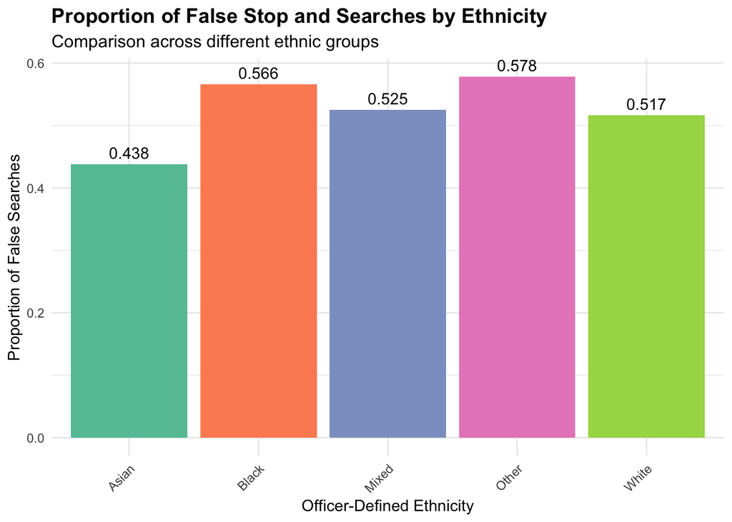

Figure 2 presents a clear visual representation of the proportion of false stops and searches across different ethnic groups, showing a marked variance that could indicate an ethnic bias. Notably, individuals identified as Black and those grouped as ‘Other’ encounter the highest rates of false stops and searches, significantly more than their Asian counterparts, who experience the lowest. This disparity calls for a critical evaluation of policing tactics to address prejudiced assumptions rooted in perceived ethnicity.

##### Figure 3

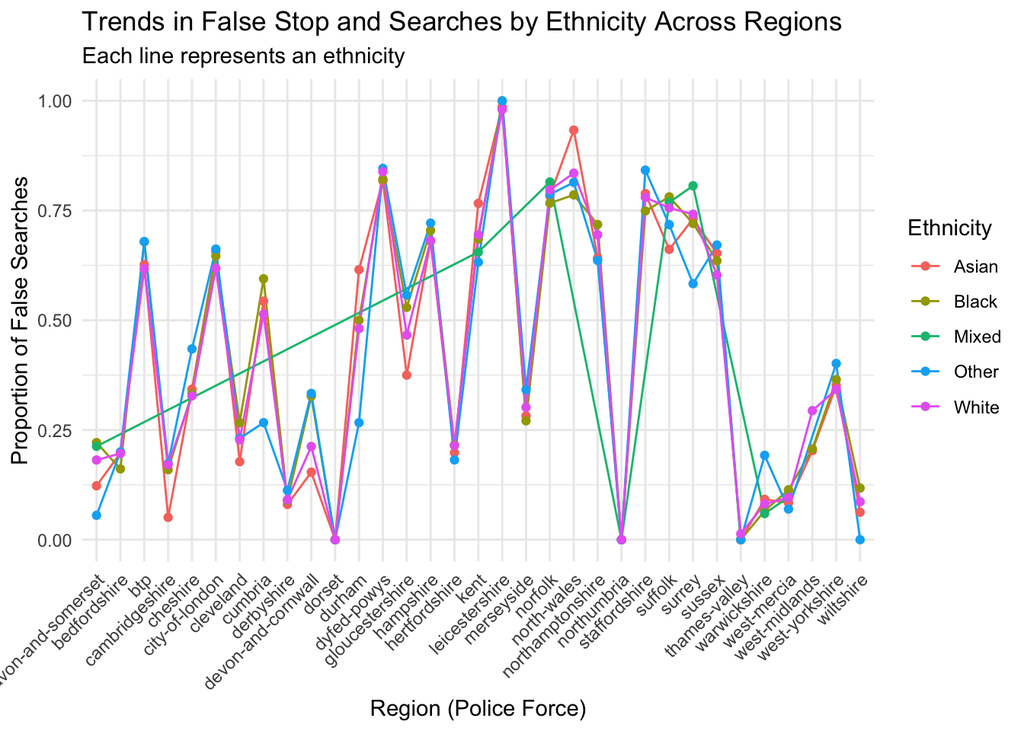

Figure 3 depicts the inconsistency of false stop and searches across regions for different ethnic groups, suggesting that the application of stop and search is not uniform. The fluctuation might reflect regional policing strategies, community relations, or social-economic factors influencing police interactions. The peaks and troughs for each ethnic line warrant a closer examination of local policing policies to understand the underlying causes of these disparities.

##### Table 1: Results of the Regression Analysis (rows 1-6)

```
## # A tibble: 6 × 5
##   term                estimate std.error statistic   p.value
##   <chr>                  <dbl>     <dbl>     <dbl>     <dbl>
## 1 (Intercept)           1.47      0.0651    22.6   8.15e-113
## 2 forcebedfordshire    -0.0284    0.123     -0.231 8.17e-  1
## 3 forcebtp             -2.03      0.0640   -31.7   2.09e-220
## 4 forcecambridgeshire   0.216     0.109      1.98  4.76e-  2
## 5 forcecheshire        -0.782     0.0783    -9.98  1.81e- 23
## 6 forcecity-of-london  -2.02      0.0773   -26.2   5.05e-151
```

### Limitations

Our analysis, while revealing, has limitations. The 2021 data provides a recent snapshot but may not capture longer-term trends. The absence of time-of-day data limits our ability to explore temporal patterns in police behavior. Some forces only record dates, not specific times, resulting in a skewed distribution of incidents around midnight. Moreover, the complexity of societal factors influencing police actions are not fully captured. Future research could benefit from a multi-dimensional approach, integrating additional variables and longitudinal data to provide a more nuanced understanding of policing biases.

## Appendix: All code in this assignment

```r
knitr::opts_chunk$set(echo = FALSE, warning = FALSE, message = FALSE)
# THIS CHUNK OF CODE PERFORMS DATA RETRIVAL FROM THE UK POLICE API. IT HAS BEEN RUN ONCE AND SAVED IN THE "police_stops_data.csv" TO REDUCE RUNTIME AND INCREASE EFFICIENCY

# loading the necessary libraries
library(httr)
library(jsonlite)
library(lubridate)

# The list of police forces to query data for
# forces <- c("avon-and-somerset", "bedfordshire", "btp", "cambridgeshire", "cheshire",
#            "city-of-london", "cleveland", "cumbria", "derbyshire", "devon-and-cornwall",
#            "dorset", "durham", "dyfed-powys", "essex", "gloucestershire", "gmp", "gwent",
#            "hampshire", "hertfordshire", "humberside", "kent", "lancashire", "leicestershire",
#            "lincolnshire", "merseyside", "metropolitan", "norfolk", "north-wales",
#            "north-yorkshire", "northamptonshire", "northumbria", "nottinghamshire", "psni",
#            "south-wales", "south-yorkshire", "staffordshire", "suffolk", "surrey",
#            "sussex", "thames-valley", "warwickshire", "west-mercia", "west-midlands",
#            "west-yorkshire", "wiltshire")

# Sequence of dates for which to query data
# date_seq <- c("2021-01", "2021-02", "2021-03", "2021-04", "2021-05",
#                "2021-06", "2021-07", "2021-08", "2021-09", "2021-10", "2021-11", "2021-12")


# Define the columns to keep
# columns_to_keep <- c("age_range", "gender", "datetime", "officer_defined_ethnicity",
               #      "type", "outcome_linked_to_object_of_search", "location.latitude",
               #      "location.longitude", "location.street.id", "location.street.name", "force")


# Initialize an empty list to store the combined data
#all_data <- list()

# Loop over each police force
#for (force in forces) {
#    force_data <- list()

# Loop over each date
#    for (date in date_seq) {
#        url <- paste0("https://data.police.uk/api/stops-force?force=", force, "&date=", date)
#        response <- GET(url)
#        if (status_code(response) == 200) {
#            data <- fromJSON(content(response, "text", encoding = "UTF-8"), flatten = TRUE)
#            if (is.data.frame(data) && nrow(data) > 0) {
#                data$force <- force  # Add the force name here

#                 Standardize columns
#                for (col in columns_to_keep) {
#                    if (!col %in% names(data)) {
#                        data[[col]] <- NA  # Add missing columns as NA
#                    }
#                }
#                data <- data[, columns_to_keep]  # Keep only the desired columns

#                force_data[[date]] <- data
#            } else {
#                warning("No data or incorrect format for ", force, " for date ", date)
#            }
#        } else {
#            warning("Failed to retrieve data for ", force, " for date ", date)
#        }
#    }


#     #Combine data frames for this force
#    if (length(force_data) > 0) {
#        all_data[[force]] <- do.call(rbind, force_data)
#    }
#}

# Combine all the data into one data frame
#combined_data <- do.call(rbind, all_data)

# Handle Missing Values
#combined_data <- na.omit(combined_data)

# Convert 'datetime' to Date format
#combined_data$datetime <- as.Date(combined_data$datetime, format="%Y-%m-%dT%H:%M:%S")

#head(combined_data)

# Save the combined data to a CSV file
#write.csv(combined_data, "police_stops_data.csv", row.names = FALSE)

# Read the data from the saved file
combined_data <- read.csv("police_stops_data.csv")

# ETHNIC COMPOSITION MAP

# Load necessary libraries
library(sf)
library(dplyr)
library(ggplot2)
library(readr)
library(viridis)


# Read the shapefile for Local Authority Districts in the UK
lad_shapefile <- st_read("Local_Authority_Districts_(May_2021)_UK_BGC/LAD_MAY_2021_UK_BGC.shp", quiet = TRUE)

# Read the CSV data
data <- read_csv2("ethnicity-composition-across-uk.csv")


# Filter and clean the data
# Remove rows with "-" in ethnicity columns and convert percentages to numeric
clean_data <- data %>%
  filter(`Asian, Asian British or Asian Welsh: Bangladesh` != "-",
                           `Asian, Asian British or Asian Welsh: Chinese` != "-",
                           `Asian, Asian British or Asian Welsh: Indian` != "-",
                           `Asian, Asian British or Asian Welsh: Pakistani`!= "-",
                           `Asian, Asian British or Asian Welsh: Other Asian` != "-",
                           `Black, Black British, Black Welsh, Caribbean or African: African` != "-",
                           `Black, Black British, Black Welsh, Caribbean or African: Caribbean` != "-",
                           `Black, Black British, Black Welsh, Caribbean or African: Other Black` != "-",
                           `Mixed or Multiple ethnic groups: White and Asian` != "-",
                           `Mixed or Multiple ethnic groups: White and Black African` != "-",
                           `Mixed or Multiple ethnic groups: White and Black Caribbean` != "-",
                           `Mixed or Multiple ethnic groups: Other Mixed or Multiple ethnic groups` != "-",
                           `Other ethnic group: Arab` != "-",
                           `Other ethnic group: Any other ethnic group` != "-")

# Convert percentages to numeric
data <- clean_data %>%
  mutate(
    `Asian, Asian British or Asian Welsh: Bangladesh` = as.numeric(gsub(",", ".", `Asian, Asian British or Asian Welsh: Bangladesh`)),
    `Asian, Asian British or Asian Welsh: Chinese` = as.numeric(gsub(",", ".", `Asian, Asian British or Asian Welsh: Chinese`)),
    `Asian, Asian British or Asian Welsh: Indian` = as.numeric(gsub(",", ".", `Asian, Asian British or Asian Welsh: Indian`)),
    `Asian, Asian British or Asian Welsh: Pakistani` = as.numeric(gsub(",", ".", `Asian, Asian British or Asian Welsh: Pakistani`)),
    `Asian, Asian British or Asian Welsh: Other Asian` = as.numeric(gsub(",", ".", `Asian, Asian British or Asian Welsh: Other Asian`)),
    `Black, Black British, Black Welsh, Caribbean or African: African` = as.numeric(gsub(",", ".", `Black, Black British, Black Welsh, Caribbean or African: African`)),
    `Black, Black British, Black Welsh, Caribbean or African: Caribbean` = as.numeric(gsub(",", ".", `Black, Black British, Black Welsh, Caribbean or African: Caribbean`)),
    `Black, Black British, Black Welsh, Caribbean or African: Other Black` = as.numeric(gsub(",", ".", `Black, Black British, Black Welsh, Caribbean or African: Other Black`)),
    `Mixed or Multiple ethnic groups: White and Asian` = as.numeric(gsub(",", ".", `Mixed or Multiple ethnic groups: White and Asian`)),
    `Mixed or Multiple ethnic groups: White and Black African` = as.numeric(gsub(",", ".", `Mixed or Multiple ethnic groups: White and Black African`)),
    `Mixed or Multiple ethnic groups: White and Black Caribbean` = as.numeric(gsub(",", ".", `Mixed or Multiple ethnic groups: White and Black Caribbean`)),
    `Mixed or Multiple ethnic groups: Other Mixed or Multiple ethnic groups` = as.numeric(gsub(",", ".", `Mixed or Multiple ethnic groups: Other Mixed or Multiple ethnic groups`)),
    `Other ethnic group: Arab` = as.numeric(gsub(",", ".", `Other ethnic group: Arab`)),
    `Other ethnic group: Any other ethnic group` = as.numeric(gsub(",", ".", `Other ethnic group: Any other ethnic group`))
  )
```

```r
# Calculate the total percentage of non-white ethnicities for each row
data <- data %>%
  rowwise() %>%
  mutate(PercentNonWhite = `Asian, Asian British or Asian Welsh: Bangladesh` +
                           `Asian, Asian British or Asian Welsh: Chinese` +
                           `Asian, Asian British or Asian Welsh: Indian` +
                           `Asian, Asian British or Asian Welsh: Pakistani` +
                           `Asian, Asian British or Asian Welsh: Other Asian` +
                           `Black, Black British, Black Welsh, Caribbean or African: African` +
                           `Black, Black British, Black Welsh, Caribbean or African: Caribbean` +
                           `Black, Black British, Black Welsh, Caribbean or African: Other Black` +
                           `Mixed or Multiple ethnic groups: White and Asian` +
                           `Mixed or Multiple ethnic groups: White and Black African` +
                           `Mixed or Multiple ethnic groups: White and Black Caribbean` +
                           `Mixed or Multiple ethnic groups: Other Mixed or Multiple ethnic groups` +
                           `Other ethnic group: Arab` +
                           `Other ethnic group: Any other ethnic group`) %>%
  ungroup()




# Merge the shapefile and CSV data
map_data <- left_join(lad_shapefile, data, by = c("LAD21CD" = "Area code"))

# Create a map visualization of the percentage of non-white ethnicities
ethnic_composition_map <- ggplot(data = map_data) +
  geom_sf(aes(fill = PercentNonWhite), color = NA) +  # No border color
  scale_fill_viridis_c(
    option = "C",  # Viridis color option
    direction = 1,  # Sets the direction of the color scale
    name = "Percent Non-White",  # Legend title
    labels = scales::percent_format(scale = 1),  # Format labels as percentages
    na.value = "grey"  # Color for NA values
  ) +
  labs(
    title = "Percentage of Non-White Ethnicities",
    caption = "Source: data.gov.uk"
  ) +
  theme_minimal() +
  theme(
    legend.position = "right",  # Adjust legend position
    plot.title = element_text(size = 14, face = "bold"),  # Title style
    plot.subtitle = element_text(size = 12)  # Subtitle style
  )

# STOP AND SERACHES DISTRIBUTION MAP

# Load necessary libraries
library(sf)
library(dplyr)
library(ggplot2)

# Read the shapefile data for administrative countries
uk_shape <- st_read('ne_10m_admin_0_countries/ne_10m_admin_0_countries.shp', quiet = TRUE)

# Filter for the United Kingdom
uk <- uk_shape %>%
  filter(ADMIN == "United Kingdom")

# Convert latitude and longitude columns in combined_data to numeric values
# This is necessary for creating spatial data from these coordinates
combined_data$location.latitude <- as.numeric(as.character(combined_data$location.latitude))
combined_data$location.longitude <- as.numeric(as.character(combined_data$location.longitude))

# Convert the combined_data dataframe into a simple feature object for spatial analysis
# Coordinates are specified, and the coordinate reference system (CRS) is set to match the UK shapefile
stops_sf <- st_as_sf(combined_data, coords = c("location.longitude", "location.latitude"),
                     crs = st_crs(uk), agr = "constant")


# Create a map visualization using ggplot2
stop_and_search_map <- ggplot() +
  geom_sf(data = uk) +  # Plot the UK map
  geom_sf(data = stops_sf, color = 'red', size = 0.6, alpha = 0.7) +  # Plot the stop and search data
  theme_minimal() +
  labs(title = "Distribution of Stop and Searches",
    caption = "Source: data.police.uk"
  ) +
  theme(
    plot.title = element_text(size = 14, face = "bold") # Title style
  )

# COMBINING THE TWO MAPS IN ONE SINGLE VISUALISATION

library(ggplot2)

# Modify map1 to remove axes
ethnic_composition_map <- ethnic_composition_map +
  coord_sf() +  # Add coordinate system for spatial data+
  theme(
    panel.grid.major = element_blank(),
    panel.grid.minor = element_blank(),
    plot.title = element_text(hjust = 0.5, size = 10),  # Adjust title size
    axis.title = element_blank(),  # Remove axis titles
    axis.text = element_blank(),   # Remove axis text
    axis.ticks = element_blank(),   # Remove axis ticks
    legend.position = "left", # Move legend to bottom
    legend.title = element_text(size = 7),  # Adjust the size of the legend title
    legend.text = element_text(size = 7),    # Adjust the size of the legend text
    legend.key.size = unit(0.75, "lines") # Adjust the size of the legend keys
  )


# Modify map2 to remove axes
stop_and_search_map <- stop_and_search_map +
  coord_sf() +  # Add coordinate system for spatial data+
  theme(
    panel.grid.major = element_blank(),
    panel.grid.minor = element_blank(),
    plot.title = element_text(hjust = 0.5, size = 10),  # Adjust title size
    axis.title = element_blank(),  # Remove axis titles
    axis.text = element_blank(),   # Remove axis text
    axis.ticks = element_blank()   # Remove axis ticks
  )

# Adjust margins of the maps
ethnic_composition_map <- ethnic_composition_map + theme(plot.margin = margin(1, 1, 1, 1, "cm"))
stop_and_search_map <- stop_and_search_map + theme(plot.margin = margin(1, 1, 1, 1, "cm"))

# Combine the plots with patchwork
library(patchwork)
combined_map_layout <- ethnic_composition_map + stop_and_search_map +
  plot_layout(ncol = 2)

# Print the combined plot
print(combined_map_layout)
# BAR CHART

# Load necessary library
library(tidyverse)

# Read the CSV file
police_stops_data <- read.csv('police_stops_data.csv')

# Creating a new variable for false stop and searches
# A false stop and search is one where the outcome is not linked to the object of search
police_stops_data$false_stop_search <- !police_stops_data$outcome_linked_to_object_of_search

# Calculate the proportion of false stop and searches for each ethnicity
ethnicity_summary <- police_stops_data %>%
  group_by(officer_defined_ethnicity) %>%
  summarise(
    total_searches = n(),
    false_searches = sum(false_stop_search),
    proportion_false_searches = false_searches / total_searches
  )
```

```r
# Plotting the proportion of false stop and searches by ethnicity
ggplot(ethnicity_summary, aes(x = officer_defined_ethnicity, y = proportion_false_searches, fill = officer_defined_ethnicity)) +
  geom_bar(stat = 'identity') +
  scale_fill_brewer(palette = "Set2") +
  geom_text(aes(label = round(proportion_false_searches, 3)), vjust = -0.5) +
  theme_minimal() +
  theme(
    axis.text.x = element_text(angle = 45, hjust = 1),
    plot.title = element_text(size = 14, face = "bold"),
    plot.subtitle = element_text(size = 12),
    legend.position = "none"
  ) +
  labs(
    title = 'Proportion of False Stop and Searches by Ethnicity',
    subtitle = 'Comparison across different ethnic groups',
    x = 'Officer-Defined Ethnicity',
    y = 'Proportion of False Searches'
  )

# LINE GRAPH WITH EACH POLICE FORCE

# Load necessary libraries
library(tidyverse)

# Read the CSV file
police_stops_data <- read.csv('police_stops_data.csv')

# Creating a new variable for false stop and searches
police_stops_data$false_stop_search <- !police_stops_data$outcome_linked_to_object_of_search

# Group by region (force) and ethnicity, and calculate proportions
regional_ethnicity_summary <- police_stops_data %>%
  group_by(force, officer_defined_ethnicity) %>%
  summarise(
    total_searches = n(),
    false_searches = sum(false_stop_search),
    proportion_false_searches = false_searches / total_searches
  ) %>%
  ungroup()

# Create and customize the line plot
ggplot(regional_ethnicity_summary, aes(x = force, y = proportion_false_searches, color = officer_defined_ethnicity, group = officer_defined_ethnicity)) +
  geom_line() +
  geom_point() +
  theme_minimal() +
  theme(axis.text.x = element_text(angle = 45, hjust = 1)) +
  labs(
    title = 'Trends in False Stop and Searches by Ethnicity Across Regions',
    subtitle = 'Each line represents an ethnicity',
    x = 'Region (Police Force)',
    y = 'Proportion of False Searches',
    color = 'Ethnicity'
  )

# REGRESSION ANALYSIS

# Load necessary libraries
library(dplyr)

# Read your data into a dataframe
# Read the CSV file into a dataframe
data <- read.csv('police_stops_data.csv')


# Define false stop and searches
# Assuming a false stop and search is when 'outcome_linked_to_object_of_search' is FALSE
data$false_stop_search <- !data$outcome_linked_to_object_of_search


# Convert categorical variables to factors
data$force <- as.factor(data$force)
data$officer_defined_ethnicity <- as.factor(data$officer_defined_ethnicity)
data$false_stop_search <- as.factor(data$outcome_linked_to_object_of_search)

# Fit a logistic regression model
logistic_model <- glm(false_stop_search ~ force + officer_defined_ethnicity, data = data, family = 'binomial')

library(broom)

# Assuming your logistic model is named logistic_model
tidied_model <- tidy(logistic_model)

# Selecting important columns
important_results <- tidied_model %>%
  select(term, estimate, std.error, statistic, p.value)

# Viewing the table
head(important_results)


# this chunk generates the complete code appendix.
# eval=FALSE tells R not to run (``evaluate'') the code here (it was already run before).
```